# Práctica 2: limpieza, análisis y representación de los datos

Cristina Liánez López y Manuel Padrón Martínez

25 de mayo, 2020

# 1. Detalles de la actividad

En esta actividad se elabora un caso práctico, consistente en el tratamiento de un conjunto de datos (en inglés, dataset), orientado a aprender a identificar los datos relevantes para un proyecto analítico y usar las herramientas de integración, limpieza, validación y análisis de las mismas.

# 2. Resolución

### 2.1. Descripción del dataset

El conjunto de datos objeto de análisis se ha obtenido a partir de un dataset libre disponible en Kaggle. Este conjunto de datos incluye información sobre diferentes marcas de vehículos nuevos y usados a la venta en los EE.UU. Los datos se obtuvieron haciendo uso de la técnica de *Web Scraping.* Está constituido por 2499 vehículos (filas o registros), de los que se han analizado 13 características (columnas) de cada uno.

### 2.2. Integración y selección de los datos de interés a analizar.

### 2.3. Limpieza de los datos

En primer lugar, procedemos a realizar la lectura del fichero en formato CSV en el que se encuentran los datos. A continuación, examinaremos el tipo de datos con los que R ha interpretado cada variable.

```r
# Carga del archivo
setwd("C:/Users/clian/Desktop/Data Science/Tipologia y ciclo de vida datos/Pract2/Lianez_Padron")
cars <-read.csv("USA_cars_datasets.csv",header=TRUE)

#muestra las primeras filas del dataset
head(cars)
```

```
##   X price     brand   model year  title_status mileage  color
## 1 0  6300    toyota cruiser 2008 clean vehicle  274117  black
## 2 1  2899      ford      se 2011 clean vehicle  190552 silver
## 3 2  5350     dodge     mpv 2018 clean vehicle   39590 silver
## 4 3 25000      ford    door 2014 clean vehicle   64146   blue
## 5 4 27700 chevrolet    1500 2018 clean vehicle    6654    red
## 6 5  5700     dodge     mpv 2018 clean vehicle   45561  white
##                   vin       lot      state country     condition
## 1   jtezu11f88k007763 159348797 new jersey     usa  10 days left
## 2   2fmdk3gc4bbb02217 166951262  tennessee     usa   6 days left
## 3   3c4pdcgg5jt346413 167655728    georgia     usa   2 days left
## 4   1ftfw1et4efc23745 167753855   virginia     usa 22 hours left
## 5   3gcpcrec2jg473991 167763266    florida     usa 22 hours left
## 6   2c4rdgeg9jr237989 167655771      texas     usa   2 days left
```

```r
#Examino el tipo de datos de cada variable
str(cars)
```

```
## 'data.frame':    2499 obs. of  13 variables:
##  $ X           : int  0 1 2 3 4 5 6 7 8 9 ...
##  $ price       : int  6300 2899 5350 25000 27700 5700 7300 13350 14600 5250 ...
##  $ brand       : Factor w/ 28 levels "acura","audi",..: 28 9 8 9 6 8 6 10 6 9 ...
##  $ model       : Factor w/ 127 levels "1500","2500",..: 26 93 76 33 1 76 87 33 72 76 ...
##  $ year        : int  2008 2011 2018 2014 2018 2018 2010 2017 2018 2017 ...
##  $ title_status: Factor w/ 2 levels "clean vehicle",..: 1 1 1 1 1 1 1 1 1 1 ...
##  $ mileage     : num  274117 190552 39590 64146 6654 ...
##  $ color       : Factor w/ 49 levels "beige","billet silver metallic clearcoat",..: 3 40 40 5 35 47 3 16 40 3 ...
##  $ vin         : Factor w/ 2495 levels "  19uua96529a004646",..: 2393 1666 1886 968 2088 1650 1194 1239 1123 1706 ...
##  $ lot         : int  159348797 166951262 167655728 167753855 167763266 167655771 167753872 167692494 167763267 167656121 ...
##  $ state       : Factor w/ 44 levels "alabama","arizona",..: 25 36 8 40 7 37 8 4 7 37 ...
##  $ country     : Factor w/ 2 levels " canada"," usa": 2 2 2 2 2 2 2 2 2 2 ...
##  $ condition   : Factor w/ 47 levels "1 days left",..: 4 40 17 21 21 17 21 19 21 17 ...
```

Puede observarse que los tipos de datos asignados automáticamente por R a las variables se corresponden con el dominio de estas.

De las 13 características registradas de cada vehículo, se ha decido prescindir de **x**, **lot** y **condition**, ya que no son atributos propios de los vehículos, sino que hacen referencia a los anuncios en los que se publicitaban a los mismos.

```r
# Prescindimos de las variables X, lot y condition
cars <- cars[,-(1)]
cars <- cars[,-(9)]
cars <- cars[,-(11)]
str(cars)
```

```
## 'data.frame':    2499 obs. of  10 variables:
##  $ price       : int  6300 2899 5350 25000 27700 5700 7300 13350 14600 5250 ...
##  $ brand       : Factor w/ 28 levels "acura","audi",..: 28 9 8 9 6 8 6 10 6 9 ...
##  $ model       : Factor w/ 127 levels "1500","2500",..: 26 93 76 33 1 76 87 33 72 76 ...
##  $ year        : int  2008 2011 2018 2014 2018 2018 2010 2017 2018 2017 ...
##  $ title_status: Factor w/ 2 levels "clean vehicle",..: 1 1 1 1 1 1 1 1 1 1 ...
##  $ mileage     : num  274117 190552 39590 64146 6654 ...
##  $ color       : Factor w/ 49 levels "beige","billet silver metallic clearcoat",..: 3 40 40 5 35 47 3 16 40 3 ...
##  $ vin         : Factor w/ 2495 levels "  19uua96529a004646",..: 2393 1666 1886 968 2088 1650 1194 1239 1123 1706 ...
##  $ state       : Factor w/ 44 levels "alabama","arizona",..: 25 36 8 40 7 37 8 4 7 37 ...
##  $ country     : Factor w/ 2 levels " canada"," usa": 2 2 2 2 2 2 2 2 2 2 ...
```

```r
head(cars)
```

```
##   price     brand   model year  title_status mileage  color                 vin
## 1  6300    toyota cruiser 2008 clean vehicle  274117  black   jtezu11f88k007763
## 2  2899      ford      se 2011 clean vehicle  190552 silver   2fmdk3gc4bbb02217
## 3  5350     dodge     mpv 2018 clean vehicle   39590 silver   3c4pdcgg5jt346413
## 4 25000      ford    door 2014 clean vehicle   64146   blue   1ftfw1et4efc23745
## 5 27700 chevrolet    1500 2018 clean vehicle    6654    red   3gcpcrec2jg473991
## 6  5700     dodge     mpv 2018 clean vehicle   45561  white   2c4rdgeg9jr237989
##        state country
## 1 new jersey     usa
## 2  tennessee     usa
## 3    georgia     usa
## 4   virginia     usa
## 5    florida     usa
## 6      texas     usa
```

#### 2.3.1. Normalización de variables

A continuación, mostraremos los valores de las variables cualitativas o categóricas mediante el uso de tablas de frecuencia. Ésto nos permitirá saber si hay valores fuera del rango o valores extraños en ellas.

```r
#variables cualitativas
table(cars$brand)
```

```
##
##           acura            audi             bmw           buick        cadillac
##               3               4              17              13              10
##       chevrolet        chrysler           dodge            ford             gmc
##             297              18             432            1235              42
## harley-davidson       heartland           honda         hyundai        infiniti
##               1               5              12              15              12
##          jaguar            jeep             kia            land           lexus
##               1              30              13               4               2
##         lincoln        maserati           mazda   mercedes-benz          nissan
##               2               1               2              10             312
##       peterbilt             ram          toyota
##               4               1               1
```

```r
table(cars$model)
```

```
##
##        1500        2500      2500hd         300        3500           5
##          39           8           1           6           4           1
##      acadia      altima      armada         bus         cab      camaro
##           1          21           4           2           8           6
##     caravan       cargo  challenger     charger     chassis    cherokee
##         102           2          44          42           4           3
##    colorado     compass     connect convertible    corvette     country
##          12           6           1           1           4           2
##       coupe     cruiser       cruze     cutaway        cx-3           d
##           6           1           2          12           1           2
##        dart   discovery        door       doors          dr         drw
##           1           1         651         148           1          10
##     durango     e-class    ecosport        edge          el     elantra
##          64           1           7          34           3           1
##     enclave      encore      energi     equinox      escape         esv
##           2           3           1          18          39           1
##  expedition    explorer       f-150       f-650       f-750      fiesta
##          28          39         219           3           1          14
##        flex       focus       forte    frontier      fusion      ghibli
##          33           9           2          14          65           1
##         glc         gle          gx      hybrid      impala     journey
##           1           2           1           5          12          61
##        juke       kicks          ld     limited           m      malibu
##           1           1           3           1           1          12
##         max      maxima         mdx         mpv      murano     mustang
##          41           3           1          87           5          29
##    nautilus        note         nvp    pacifica   passenger  pathfinder
##           1           2           1           3           3          22
##      pickup     pioneer          pk          q5         q70      ranger
##          15           1           5           1           1           6
## road/street       rogue          se       sedan      sentra      series
##           1          54           1           4          28           8
##    sl-class       sonic     sorento        soul       spark       sport
##           1           2           5           1           1          40
##    sportage         srw         srx    suburban    sundance         suv
##           1          38           1          16           1           1
##       tahoe      taurus       titan       trail     transit    traverse
##           9          10           5           1          41           6
##        trax       truck     utility         van        vans      vehicl
##           8           4           1          46           2           1
##       versa        volt       wagon          x3          xd         xt5
##          34           2          30           2           1           1
##      xterra
##           1
```

```r
table(cars$title_status)
```

```
##
##     clean vehicle salvage insurance
##              2336               163
```

```r
table(cars$color)
```

```
##
##                                   beige        billet silver metallic clearcoat
##                                       5                                       3
##                                   black                         black clearcoat
##                                     516                                       2
##                                    blue                  bright white clearcoat
##                                     151                                       2
##                                   brown                                burgundy
##                                      15                                       1
##                             cayenne red                                charcoal
##                                       2                                      18
##                                  color:                      competition orange
##                                       5                                       1
##                               dark blue                           glacier white
##                                       1                                       1
##                                    gold                                    gray
##                                      19                                     395
##                                   green                                   guard
##                                      24                                       1
##                            ingot silver                   ingot silver metallic
##                                       1                                       4
##                     jazz blue pearlcoat                      kona blue metallic
##                                       1                                       1
##                              light blue                          lightning blue
##                                       1                                       1
##                       magnetic metallic                                  maroon
##                                       6                                       1
##                         morningsky blue                                no_color
##                                       1                                      61
##                               off-white                                  orange
##                                       2                                      20
##                            oxford white                             pearl white
##                                       4                                       1
##                           phantom black                                  purple
##                                       1                                       1
##                                     red royal crimson metallic tinted clearcoat
##                                     192                                       1
##                                ruby red      ruby red metallic tinted clearcoat
##                                       1                                       2
##                            shadow black                                  silver
##                                       5                                     300
##                             super black                                     tan
##                                       3                                       1
##                            toreador red                  triple yellow tri-coat
##                                       1                                       3
##                               turquoise                   tuxedo black metallic
##                                       1                                       2
##                                   white        white platinum tri-coat metallic
##                                     707                                       2
##                                  yellow
##                                       9
```

```r
table(cars$state)
```

```
##
##        alabama        arizona       arkansas     california       colorado
##             17             33             12            190             21
##    connecticut        florida        georgia          idaho       illinois
##             25            246             51              2            113
##        indiana         kansas       kentucky      louisiana       maryland
##             14              4              9             11              4
##  massachusetts       michigan      minnesota    mississippi       missouri
##             27            169            119             24             46
##        montana       nebraska         nevada  new hampshire     new jersey
##              1              4             85              4             87
##     new mexico       new york north carolina           ohio       oklahoma
##              4             58            146             31             71
##        ontario         oregon   pennsylvania   rhode island south carolina
##              7             27            299              2             64
##      tennessee          texas           utah        vermont       virginia
##             26            214             10              2             90
##     washington  west virginia      wisconsin        wyoming
##             14             21             94              1
```

```r
table(cars$country)
```

```
##
##  canada     usa
##       7    2492
```

Los colores se van a clasificar en los siguientes valores: *beige, black, blue, brown, orange, gold, red, silver, white, gray, green, purple, yellow, no-color*

```r
cars$color <- str_replace(cars$color, ".*beige.*", "beige")
cars$color <- str_replace(cars$color, ".*black.*", "black")
cars$color <- str_replace(cars$color, ".*blue.*", "blue")
cars$color <- str_replace(cars$color, ".*brown.*", "brown")
cars$color <- str_replace(cars$color, ".*orange.*", "orange")
cars$color <- str_replace(cars$color, ".*gold.*", "gold")
cars$color <- str_replace(cars$color, ".*red.*", "red")
cars$color <- str_replace(cars$color, ".*silver.*", "silver")
cars$color <- str_replace(cars$color, ".*white.*", "white")
cars$color <- str_replace(cars$color, ".*gray.*", "gray")
cars$color <- str_replace(cars$color, ".*green.*", "green")
cars$color <- str_replace(cars$color, ".*purple.*", "purple")
cars$color <- str_replace(cars$color, ".*yellow.*", "yellow")
cars$color <- str_replace(cars$color, "burgundy", "red")
cars$color <- str_replace(cars$color, "charcoal", "black")
cars$color <- str_replace(cars$color, "color:", "no_color")
cars$color <- str_replace(cars$color, "maroon", "brown")
cars$color <- str_replace(cars$color, "magnetic metallic", "black")
cars$color <- str_replace(cars$color, "royal crimson metallic tinted clearcoat", "purple")
cars$color <- str_replace(cars$color, "turquoise", "blue")
cars$color <- str_replace(cars$color, "tan", "beige")
cars$color <- str_replace(cars$color, "guard", "black")

table(cars$color)
```

```
##
##    beige    black     blue    brown     gold     gray    green no_color
##        6      554      158       16       19      395       24       66
##   orange   purple      red   silver    white   yellow
##       21        2      199      308      719       12
```

#### 2.3.2. Valores perdidos

¿Los datos contienen ceros o elementos vacíos? ¿Cómo gestionarías cada uno de estos casos?

```r
# valores perdidos(0 o vacíos)
#Con la siguiente instrucción vemos si hay registros que están incompletos
complete.cases(cars)
```

[output not shown]

[output cut: 164 more lines]

```r
#Analizamos valores perdidos
sapply(cars, function(x) sum(is.na(x)))
```

```
##        price        brand        model         year title_status      mileage
##            0            0            0            0            0            0
##        color          vin        state      country
##            0            0            0            0
```

```r
sapply(cars, function(x) sum(x == 0))
```

```
##        price        brand        model         year title_status      mileage
##           43            0            0            0            0            6
##        color          vin        state      country
##            0            0            0            0
```

En primer lugar, hemos comprobado si hay registros incompletos, es decir, en los que en alguno de sus atributos no se haya introducido valor. Con la instrucciones ejecutada, se comprueba que no hay ninguno, ya que no se ha obtenido ningún valor a **FALSE**.

En segundo lugar, se ha analizado en cada una de las variables cuantitativas si existen valores almacenados equivalentes a 0 o NA. En el caso del precio, se han detectado 43 registros cuyo precio es 0; y para el caso del kilometraje, se han encontrado 6 registros con este mismo valor.

En el caso de la variable *price*, son claramente valores perdidos ya que no tiene sentido que el precio de venta fijado sea de 0$ cuando la naturaleza de los anuncios es la venta de los vehículos. Será necesario imputar los valores de estas variables en estos registros.

En el caso de la variable *mileage* cuyo valor es 0, se ha mirado el valor del atributo *year*, puesto que si éste valor se corresponde con coches del 2020, el valor registrado en el atributo *mileage* puede ser correcto ya que se trataría de vehículos nuevos que no han recorrido ninguna milla aún.

```r
years <- subset(cars$year, subset = cars$mileage == 0)
print(years)
```

```
## [1] 2004 1994 2012 1993 2013 2017
```

Trás realizar la comprobación, vemos que no es así en ninguno de los casos, es decir, son vehículos con cierta antigüedad, por lo que el valor a 0 de *mileage* se corresponde con un valor perdido, que deberíamos de imputar.

Para la imputación de los valores perdidos se empleará un método basado en la similitud o diferencia entre los registros: la imputación basada en k vecinos más próximos (en inglés, kNN-imputation). La elección de esta alternativa se realiza bajo la hipótesis de que nuestros registros guardan cierta relación. No obstante, es mejor trabajar con datos “aproximados” que con los propios elementos vacíos, ya que obtendremos análisis con menor margen de error.

```r
#primero hay que sustituir los valores 0 por NA
cars$price <- ifelse(cars$price == 0, NA, cars$price)
cars$mileage <- ifelse(cars$mileage == 0, NA, cars$mileage)
sapply(cars, function(x) sum(is.na(x)))
```

```
##        price        brand        model         year title_status      mileage
##           43            0            0            0            0            6
##        color          vin        state      country
##            0            0            0            0
```

```r
#imputamos los valores NA usando el método kNN
cars$price <- kNN(cars)$price
cars$mileage <- kNN(cars)$mileage
#comprobamos
sapply(cars, function(x) sum(is.na(x)))
```

```
##        price        brand        model         year title_status      mileage
##            0            0            0            0            0            0
##        color          vin        state      country
##            0            0            0            0
```

```r
sapply(cars, function(x) sum(x == 0))
```

```
##        price        brand        model         year title_status      mileage
##            0            0            0            0            0            0
##        color          vin        state      country
##            0            0            0            0
```

#### 2.3.3. Valores extremos.

Los valores extremos o outliers son aquellos que parecen no ser congruentes si los comparamos con el resto de los datos. Para identificarlos, utilizaremos la representación mediante un diagrama de caja.

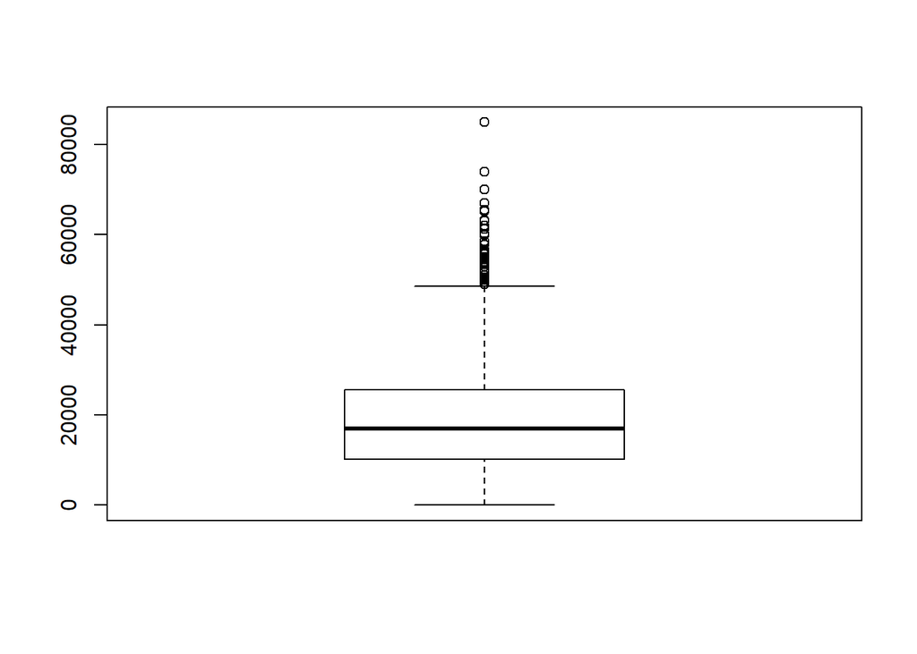

```r
boxplot(cars$price)
```

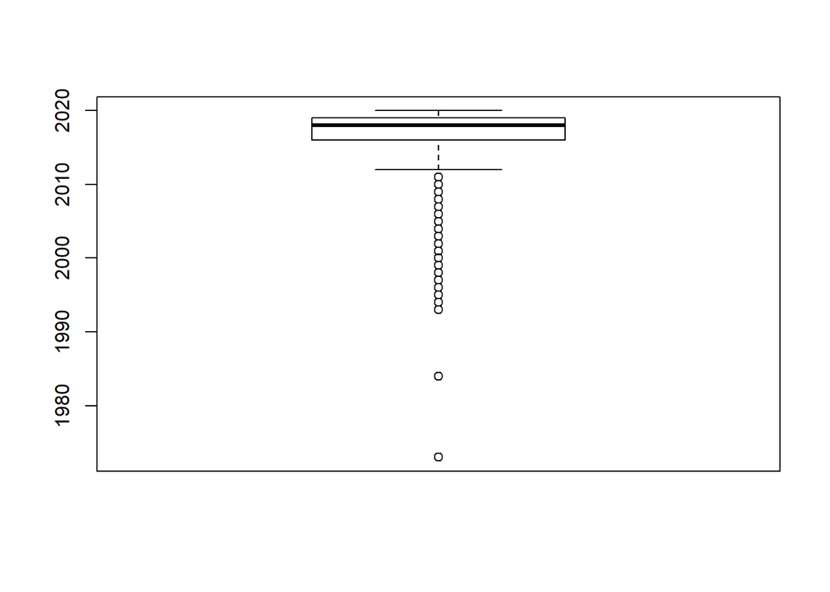

```r
boxplot(cars$year)
```

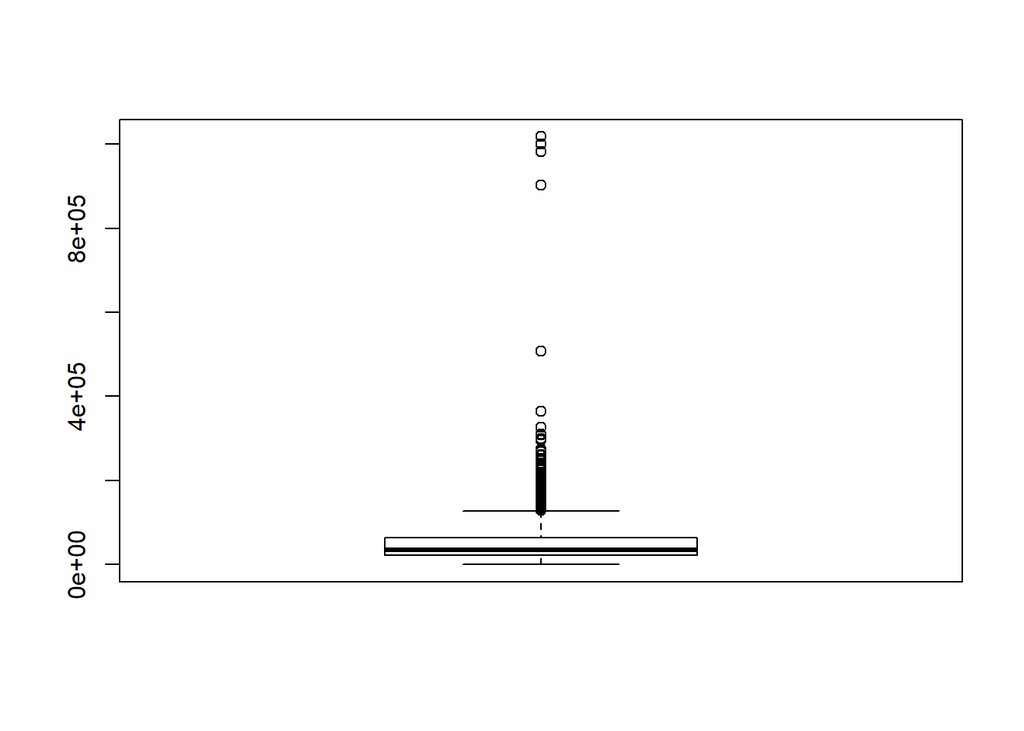

```r
boxplot(cars$mileage)
```

```r
summary(cars$price)
```

```
##    Min. 1st Qu.  Median    Mean 3rd Qu.    Max.
##      25   10200   16900   18786   25556   84900
```

```r
summary(cars$year)
```

```
##    Min. 1st Qu.  Median    Mean 3rd Qu.    Max.
##    1973    2016    2018    2017    2019    2020
```

```r
summary(cars$mileage)
```

```
##    Min. 1st Qu.  Median    Mean 3rd Qu.    Max.
##       1   21686   35493   52917   64141 1017936
```

En los tres diagramas anteriores se observan bastantes valores outliers. Ésto es debido a que el rango de valores de las tres variables es bastante amplio. Si revisamos los datos y los comparamos con los valores resumen de cada variable, llegamos a la conclusión de que son valores posibles. Por tanto, se mantendrán tal y como están recogidos.

### 2.5. Representación de los resultados a partir de tablas y gráficas.

### 2.6. Conclusiones

### 2.7. Crear el archivo procesado.

# 3. Recursos

1. Calvo M., Subirats L., Pérez D. (2019). Introducción a la limpieza y análisis de los datos. Editorial UOC.
2. Dalgaard, P. (2008). Introductory statistics with R. Springer Science & Business Media.
3. Megan Squire (2015). Clean Data. Packt Publishing Ltd.
4. Jiawei Han, Micheine Kamber, Jian Pei (2012). Data mining: concepts and techniques. Morgan Kaufmann.
5. Jason W. Osborne (2010). Data Cleaning Basics: Best Practices in Dealing with Extreme Scores. Newborn and Infant Nursing Reviews; 10 (1): pp. 1527-3369.
6. Wes McKinney (2012). Python for Data Analysis. O’Reilley Media, Inc.
7. Vegas, E. (2017). Preprocesamiento de datos. Material UOC.
8. Gibergans, J. (2017). Regresión lineal múltiple. Material UOC.
9. Rovira, C. (2008). Contraste de hipótesis. Material UOC.

Test for homogeneity of variances - Lavene’s test and the Fligner Killeen test (2016)[en línea]. bioSt@TS. [Consulta: 26 de diciembre de 2017] https://biostats.w.uib.no/test-for-homogeneity-of-variances-levenes-test/